# Merging and reshaping datasets; error handling

Pablo Barbera

August 3, 2018

## Merging datasets

Two or more data frames can be combined into a single one according to the values of a single variables using the `merge` function.

```r
students <- data.frame(name = c("Paul", "Peter", "Amy", "Megan", "Selena"),
                age = c(18, 19, 18, 20, 21),
                stringsAsFactors=FALSE)
grades <- data.frame(name = c("Amy", "Megan", "Peter", "Drew"),
                     grade = c("A", "B+", "A-", "B"),
                     stringsAsFactors=FALSE)

merge(students, grades)
```

```
##    name age grade
## 1   Amy  18     A
## 2 Megan  20    B+
## 3 Peter  19    A-
```

```r
# we can be more specific about how to merge
merge(students, grades, by="name")
```

```
##    name age grade
## 1   Amy  18     A
## 2 Megan  20    B+
## 3 Peter  19    A-
```

```r
# if the common variable has different names, we need to specify it
grades <- data.frame(student = c("Amy", "Megan", "Peter", "Drew"),
                     grade = c("A", "B+", "A-", "B"),
                     stringsAsFactors=FALSE)
merge(students, grades, by.x="name", by.y="student")
```

```
##    name age grade
## 1   Amy  18     A
## 2 Megan  20    B+
## 3 Peter  19    A-
```

Note that by default `merge` will only return rows that are present in both dataset; but we can change that default behavior. For the non-matches, the returned value will be `NA`.

```r
merge(students, grades, by.x="name", by.y="student", all.x=TRUE)
```

```
##     name age grade
## 1    Amy  18     A
## 2  Megan  20    B+
## 3   Paul  18  <NA>
## 4  Peter  19    A-
## 5 Selena  21  <NA>
```

```r
merge(students, grades, by.x="name", by.y="student", all.y=TRUE)
```

```
##    name age grade
## 1   Amy  18     A
## 2  Drew  NA     B
## 3 Megan  20    B+
## 4 Peter  19    A-
```

```r
merge(students, grades, by.x="name", by.y="student", all=TRUE)
```

```
##     name age grade
## 1    Amy  18     A
## 2   Drew  NA     B
## 3  Megan  20    B+
## 4   Paul  18  <NA>
## 5  Peter  19    A-
## 6 Selena  21  <NA>
```

What happens if names do not have exactly the same spelling? We can try some fuzzy string matching based on the Levenshtein (or edit) distance between strings. See `?adist`

```r
students <- data.frame(name = c("Paul", "Pete", "Amie", "Meghan", "Selena"),
                age = c(18, 19, 18, 20, 21),
                stringsAsFactors=FALSE)
grades <- data.frame(name = c("Amy", "Megan", "Peter", "Drew"),
                     grade = c("A", "B+", "A-", "B"),
                     stringsAsFactors=FALSE)

# probably there are better ways to code this...
students$grade <- NA

for (i in 1:nrow(students)){
  dist <- adist(students$name[i], grades$name)
  if (any(dist<4)){
    students$grade[i] <- grades$grade[which.min(dist)]
  }
}

students
```

```
##     name age grade
## 1   Paul  18  <NA>
## 2   Pete  19    A-
## 3   Amie  18     A
## 4 Meghan  20    B+
## 5 Selena  21  <NA>
```

```r
students <- data.frame(name = c("Paul", "Peter", "Amy", "Megan", "Selena"),
                age = c(18, 19, 18, 20, 21),
                stringsAsFactors=FALSE)
merge(students, grades)
```

```
##    name age grade
## 1   Amy  18     A
## 2 Megan  20    B+
## 3 Peter  19    A-
```

To learn more about merging datasets based on strings, see the `RecordLinkage` package.

Another package that is very useful is `countrycode`, which contains a data frame with pretty much every potential country code you may want to use.

## Reshaping datasets

We often want to convert the format in which a data frame is structured. For example, we may to compute the average value of a variable, grouped by values of a different variable. Let’s see some examples using the `aggregate` function:

```r
d <- read.csv("~/data/unvoting.csv", stringsAsFactors=F)

aggregate(idealpoint ~ CountryAbb, data=d, FUN=mean)
```

```
##     CountryAbb   idealpoint
## 1          AAB -0.321975346
## 2          AFG -0.743184827
## 3          ALB -0.731741191
## 4          ALG -1.072331516
## 5          AND  0.997624350
## 6          ANG -0.834550724
## 7          ARG  0.466773197
## 8          ARM  0.263951907
## 9          AUL  1.439329514
## 10         AUS  0.972567741
## 11         AZE -0.054940797
## 12         BAH -0.652265926
## 13         BAR -0.025874241
## 14         BEL  1.643699421
```

[output cut: 183 more lines]

```r
aggregate(idealpoint ~ CountryAbb, data=d, FUN=median)
```

```
##     CountryAbb   idealpoint
## 1          AAB -0.316500800
## 2          AFG -0.708525450
## 3          ALB -1.375605000
## 4          ALG -1.078160000
## 5          AND  0.956633800
## 6          ANG -0.687650900
## 7          ARG  0.466451900
## 8          ARM  0.217508100
## 9          AUL  1.382966000
## 10         AUS  0.939241700
## 11         AZE -0.060395960
## 12         BAH -0.662515050
## 13         BAR -0.118212700
## 14         BEL  1.676815500
```

[output cut: 183 more lines]

```r
aggregate(PctAgreeRUSSIA ~ Year, data=d, FUN=mean)
```

```
##    Year PctAgreeRUSSIA
## 1  1946      0.3616732
## 2  1947      0.3826490
## 3  1948      0.2794649
## 4  1949      0.3772119
## 5  1950      0.3118654
## 6  1951      0.4015296
## 7  1952      0.3453688
## 8  1953      0.5059253
## 9  1954      0.4809033
## 10 1955      0.5027162
## 11 1956      0.3456083
## 12 1957      0.4344091
## 13 1958      0.4835314
## 14 1959      0.4738003
```

[output cut: 52 more lines]

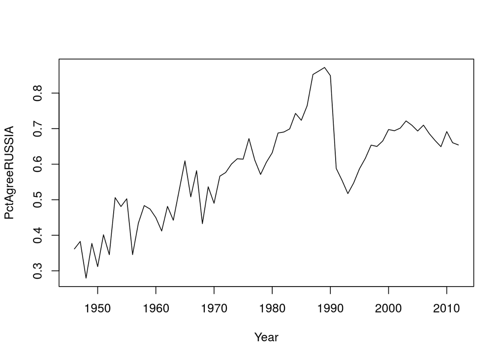

```r
plot(aggregate(PctAgreeRUSSIA ~ Year, data=d, FUN=mean), type="l")
```

```r
aggregate(idealpoint ~ CountryAbb, data=d, FUN=length)
```

```
##     CountryAbb idealpoint
## 1          AAB         32
## 2          AFG         66
## 3          ALB         56
## 4          ALG         50
## 5          AND         20
## 6          ANG         37
## 7          ARG         66
## 8          ARM         22
## 9          AUL         66
## 10         AUS         56
## 11         AZE         22
## 12         BAH         42
## 13         BAR         47
## 14         BEL         66
```

[output cut: 183 more lines]

The other type of reshaping process is transforming a dataset from long (our preferred format!) to wide; and the other way around.

```r
dd <- d[d$CountryAbb %in% c("HUN", "AUS") & d$Year %in% 2010:2012,
        c("Year", "CountryAbb", "idealpoint")]

# converting to wide format
library(reshape)
(dc <- cast(dd, CountryAbb ~ Year, value="idealpoint"))
```

```
##   CountryAbb      2010      2011      2012
## 1        AUS 0.7295488 0.7629837 0.7484664
## 2        HUN 1.0033000 0.9294886 1.0378380
```

```r
# converting back to long format
melt(dc, id.vars=c("CountryAbb", "Year"))
```

```
##         CountryAbb     value Year
## X2010          AUS 0.7295488 2010
## X2010.1        HUN 1.0033000 2010
## X2011          AUS 0.7629837 2011
## X2011.1        HUN 0.9294886 2011
## X2012          AUS 0.7484664 2012
## X2012.1        HUN 1.0378380 2012
```

## Error handling

When collecting data from the web, we need to expect the best but always prepare for the worst. You don’t want to leave your computer scraping data overnight just to wake up and discover there was an error with one the websites you were scraping and no data was downloaded.

To deal with these issues, we can use some of the options that R offers to handle errors.

```r
# this will give an error
for (i in 1:10){
  message(i)
  readLines("file.json")
}
```

We can use `try` to ignore any error that the function may return.

```r
# try, but not saving output of error
for (i in 1:10){
  message(i)
  try(readLines("file.json"))
}
```

```
## 1
```

```
## 2
```

```
## 3
```

```
## 4
```

```
## 5
```

```
## 6
```

```
## 7
```

```
## 8
```

```
## 9
```

```
## 10
```

But generally, `tryCatch` is better because it will let us store the error message and react in response to it

```r
for (i in 1:10){
  message(i)
  error <- tryCatch(readLines("file.json"), error=function(e) e)
  if (grepl("Error in file", as.character(error))){
    message("Error! Maybe the file does not exist?")
  }
}
```

```
## 1
```

```
## Error! Maybe the file does not exist?
```

```
## 2
```

```
## Error! Maybe the file does not exist?
```

```
## 3
```

```
## Error! Maybe the file does not exist?
```

```
## 4
```

```
## Error! Maybe the file does not exist?
```

```
## 5
```

```
## Error! Maybe the file does not exist?
```

```
## 6
```

```
## Error! Maybe the file does not exist?
```

```
## 7
```

```
## Error! Maybe the file does not exist?
```

```
## 8
```

```
## Error! Maybe the file does not exist?
```

```
## 9
```

```
## Error! Maybe the file does not exist?
```

```
## 10
```

```
## Error! Maybe the file does not exist?
```

Let’s see it in the wild…

```r
library(tweetscores)
accounts <- c("realDonaldTru", "HillaryClinton", "BernieSanders", "tedcruz")
load("~/my_oauth")

while (length(accounts) > 0){
  # sample randomly one account to get tweets
  new.user <- sample(as.character(accounts), 1)
  message(new.user)

  error <- tryCatch(friends <- getFriends(screen_name=new.user,
                                          oauth=my_oauth,
                                          verbose = TRUE), error=function(e) e)
  if (inherits(error, 'error')) {
    cat("Error! On to the next one...")
    next
  }
  fname <- paste0("~/data/", new.user, '.rdata')
  save(friends, file=fname)
  accounts <- accounts[-which(accounts %in% new.user)]
}
```